# Oportunidades de Inversion de la empresa Mauser

El análisis de los datos de exportación de plástico y polietileno de alta densidad en Colombia para el año 2023 revela que el total anual del Valor FOB (COP) es aproximadamente 6,695,680,238,559 COP. Este valor representa la suma total de los valores de todas las exportaciones de plástico y sus manufacturas en términos de pesos colombianos, ofreciendo una perspectiva sobre el tamaño del mercado de exportaciones de plástico en Colombia.

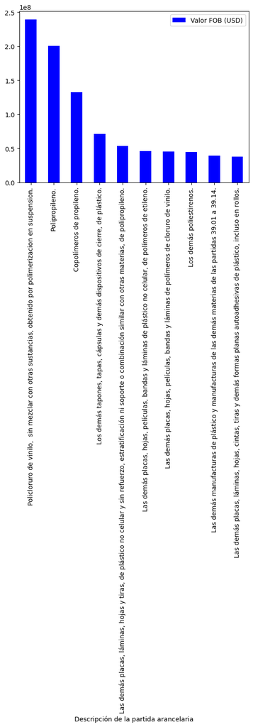

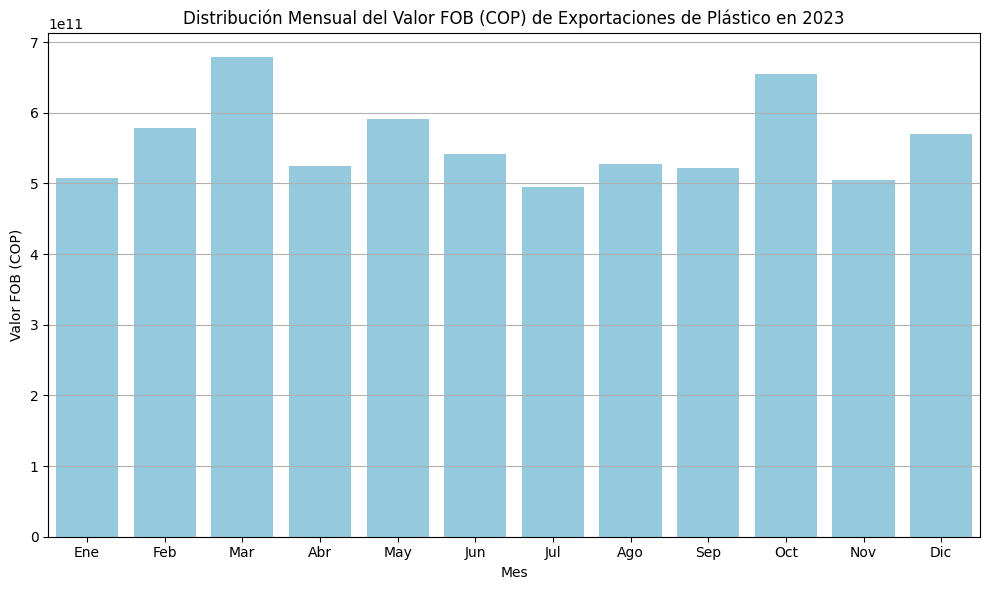

```
(6695680238559.311,
 Mes
 1     5.083397e+11
 2     5.778044e+11
 3     6.791958e+11
 4     5.248936e+11
 5     5.905242e+11
 6     5.415351e+11
 7     4.948350e+11
 8     5.277812e+11
 9     5.215527e+11
 10    6.555582e+11
 11    5.042644e+11
 12    5.693959e+11
 Name: Valor FOB (COP), dtype: float64)
```

El análisis del Valor FOB Total por Partida Arancelaria revela los productos de plástico y polietileno de alta densidad con mayor valor de exportación en Colombia durante el año 2023:

- Policloruro de Vinilo (PVC), sin mezclar con otras sustancias: Este producto lidera con un valor FOB total de aproximadamente 1.03 billones de COP. Indica la importancia del PVC en el mercado internacional, especialmente en aplicaciones de construcción, embalaje, y bienes de consumo.
- Polipropileno: Con un valor FOB de aproximadamente 868 mil millones de COP, refleja su amplio uso en una variedad de industrias, incluyendo embalaje, automotriz, textiles, y más.
- Copolímeros de Propileno: Este producto tiene un valor FOB de aproximadamente 575 mil millones de COP, lo que subraya su relevancia en aplicaciones que requieren materiales con propiedades específicas.
- Tapones, Tapas, Cápsulas y Otros Dispositivos de Cierre de Plástico: Con un valor FOB de aproximadamente 306 mil millones de COP, destacan la importancia de estos componentes en la industria de embalaje y bebidas.
- Placas, Láminas, Hojas y Tiras de Plástico de Polipropileno: Con un valor FOB de aproximadamente 232 mil millones de COP, indican la demanda de materiales de polipropileno en diversas aplicaciones industriales y comerciales.
- Placas, Hojas, Películas, Bandas y Láminas de Plástico de Polímeros de Etileno: Con un valor FOB de aproximadamente 200 mil millones de COP, reflejan su uso en embalajes flexibles, agricultura, y más.
- Placas, Hojas, Películas, Bandas y Láminas de Polímeros de Cloruro de Vinilo (PVC): Con un valor FOB similar al anterior, destacan la versatilidad del PVC en diversas aplicaciones.
- Poliestirenos: Con un valor FOB de aproximadamente 192 mil millones de COP, subraya su uso en embalaje, aislamiento, y artículos desechables.
- Manufacturas de Plástico: Con un valor FOB de aproximadamente 170 mil millones de COP, incluye una amplia gama de productos manufacturados.
- Placas, Láminas, Hojas, y Formas Planas Autoadhesivas de Plástico: Con un valor FOB de aproximadamente 164 mil millones de COP, indican la demanda de estos materiales en la industria de la publicidad, señalización, y decoración.

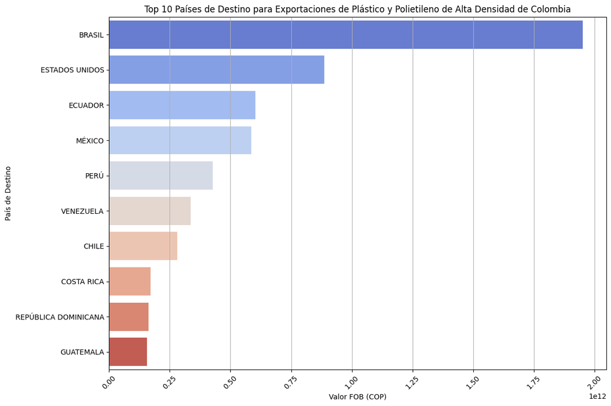

Brasil aparece como el principal destino de estas exportaciones, seguido por Estados Unidos y Ecuador. Estos tres países tienen las barras más largas, lo que indica que son los mercados más grandes para los productos de plástico colombianos según el valor FOB. México y Perú también son destinos significativos, aunque con valores menores en comparación con los tres primeros.

Los países que completan la lista de los 10 principales destinos incluyen a Venezuela, Chile, Costa Rica, República Dominicana y Guatemala. Aunque estos países reciben una porción más pequeña de las exportaciones en términos de valor FOB en comparación con los líderes del gráfico, siguen siendo mercados importantes para Colombia.

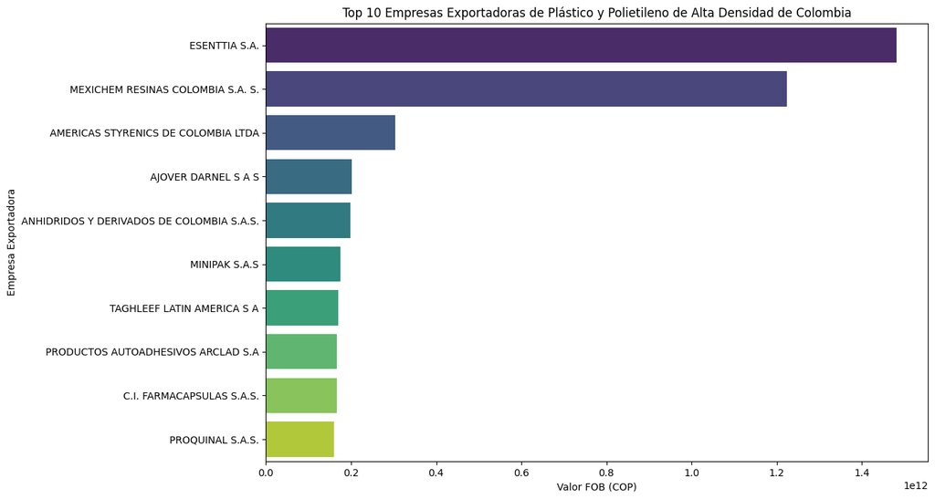

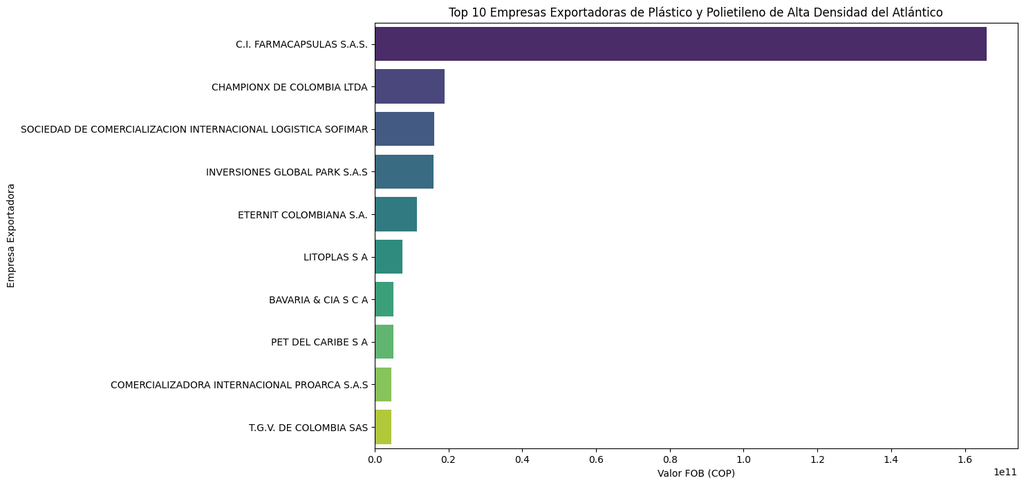

Concentración del Mercado: La entidad predominante, ESENTTIA S.A., parece tener una posición de liderazgo notable, lo cual podría indicar una alta concentración de mercado. Esto podría sugerir economías de escala significativas que permiten a ESENTTIA S.A. reducir costos y ofrecer precios competitivos en los mercados internacionales o una especialización en un nicho de productos de alto valor.

Competencia y Diversificación: La presencia de otras empresas con valores de exportación más bajos podría reflejar una competencia saludable dentro del sector. La diversificación en términos de tamaño y capacidad de exportación entre estas empresas puede contribuir a la resiliencia del sector frente a los choques económicos, ya que no está exclusivamente dependiente de un solo actor.

Para el caso atlanticense, FARMACAPSULAS domina el sector, aun asi, las empresas mas altas son empresas cartageneras.